# Mission planning

Suggested workflows for the mission planning tools

This page is meant to provide some examples of how the mission planning piloting functions maybe be used ahead of a planned mission. The below sections include examples for creating a `targets` file (the text file list of waypoints to be uploaded to the glider for navigation), creating a planned mission map, plotting a bathymetry profile for the planned track, and summarizing total mission distance and duration.

All code on this page is compiled in the [`workflow_missionTrackPlanning.m`](https://github.com/sfregosi/agate/tree/main/agate/example_workflows/workflow_missionTrackPlanning.m) in the `agate\example_workflows` folder.

Details for each function used below (inputs, outputs, etc) are available within the standard MATLAB-type documentation in the header of each function and include a detailed description, info on input and output arguments, and examples. These details can be pulled up by typing `doc function` or `help function` within the MATLAB Command Window.

### Initialization

To run any of the *agate* functions, the toolbox must be initialized with a configuration file.

No configuration file yet? Go to the Configuration Guide. The examples on this page include some plotting, so the `OPTIONAL - plotting` section must be complete.

```matlab
% make sure agate is on the path!

% initialize with specified configuration file, 'agate_config.cnf'
CONFIG = agate('agate_config.cnf');

% OR

% initialize with prompt to select configuration file
CONFIG = agate;
```

<sub>Back to top</sub>

### Create planned track using Google Earth Pro

Use Google Earth Pro (the desktop app) to plan a mission trackline and save it as a `.kml`.

- Create a path object by navigating to the *Add* menu and selecting *Path*
- A popup will appear where you can name the path
- While the popup is still the top window, the cursor will become a square; can click anywhere on the map to make a waypoint
- Continue to click to make the desired waypoints
- Waypoints can be moved by clicking and dragging
- Right-clicking on a given waypoint will delete it
- View the total track length under the *Measurements* tab
- Once you are happy with the track, hit *Ok* in the popup

The path must be saved as a `.kml` containing just a single path/track. To properly save:

- Within Google Earth, right-click on the path name in the panel on the left hand side
- Select *Save place as*
- Change the file type from `.kmz` to `.kml` and hit *Save*

An example is located in [`agate\example_workflows\exampleTrack.kml`](https://github.com/sfregosi/agate/tree/main/agate/example_workflows/exampleTrack.kml)

[figure not shown]

Figure 1: Example path in Google Earth saved as a `.kml` and ready to be converted to a `targets` file.

### Create `targets` file from .kml

The `makeTargetsFile` function will read in an existing `.kml` (that contains a single path) and use it to create a properly formatted Seaglider `targets` file. The generated targets file will be named `targets_` plus the name of the `.kml` file (*e.g.*, `targets_exampleTrack`). Note, this file will have no extension, but can be viewed in any text editor. It will contain header information with the glider and mission information defined in `CONFIG`, the date it was created, and the radius, in meters, as defined with the `'radius'` input argument (default is 2000 m).

```
/ Targets file for mission sgXXX_Location_Mon20XX
/ Created on YYYY-mm-dd HH:MM UTC
/ Deployment will take place at WP01, recovery at RECV
/ template WPxx lat=DDMM.MMMM lon=DDDMM.MMMM radius=XXXX goto=WPzz
```

Waypoint names can be generated one of three ways:

**1. alphanumeric**: specify a character string (alpha) prefix in the function call and alphanumeric names will be created automatically. *A string `'WP'` is the default option.*

**2. file**: list the desired waypoint names within a simple `.txt` file, with one name per line and the number of waypoint names must equal the number of waypoints in the `.kml`; the function will prompt to select the file. An example can be found in [`agate\example_workflows\exampleTrackWaypointNames.txt`](https://github.com/sfregosi/agate/tree/main/agate/example_workflows/exampleTrackWaypointNames.txt)

**3. manual**: waypoint names are manually entered in the Command window within the function call

```matlab
% this function uses name-value pairs for optional arguments. If an argument is
% not specified, the default will be used
% CONFIG and kmlFile are not optional, but kmlFile may be set to empty [] to
% trigger a prompt to select the .kml file
% Set the waypoint naming via the 'method' argument. The alphanumeric method
% starting with 'WP' is the default
% Set the raidus via the 'radius' argument. Default is 2000.

% specify file name to .kml track
kmlFile = fullfile(CONFIG.path.mission, 'exampleTrack.kml');

% use 1 of 3 options to name waypoints

% (1) alphanumeric/prefix-based automated naming
alphaNum = 'WPT'; % Any few letters make easy-to-reference and -read options
targetsOut = makeTargetsFile(CONFIG, kmlFile, 'method', alphaNum, 'radius', 1000);

% OR
% (2) use a text file with list of waypoint names; will prompt to select .txt
targetsOut = makeTargetsFile(CONFIG, kmlFile, 'method', 'file', 'radius', 1000);

% OR
% (3) manually enter in command window when prompted
targetsOut = makeTargetsFile(CONFIG, kmlFile, 'method', 'manual', 'radius', 1000);
```

<sub>Back to top</sub>

### Plot planned track

The `mapPlannedTrack` function will create a simple map of the planned track with labeled waypoints. This function requires map extent (lat/lon limits) to be defined in the configuration file. Optionally, a north arrow and scale bar location can be defined in the configuration file. For more help setting those parameters, see the Map Help page.

NOTE: This function sets the arguments using *name-value* pairs because most of them are optional. So each is defined by the name of the argument in single quotes (e.g., `'bathy'`) followed by a comma and then the value for the argument (e.g., `'C:\bathyFile.tiff'`). Use `doc mapPlannedTrack` to see all possible arguments.

A bathymetric basemap is optional and is toggled on or off with the `bathy` argument. Bathymetry will be plotted if `bathy` is set to 1 or to a fullfile path to a bathymetry `.tiff` file. The specified file must cover the area of the track. If set to 1 it will first look for a file specified in the configuration file (`CONFIG.map.bathyFile`) otherwise it will prompt to select a file. See Dependencies - Basemap rasters for more info on how to select and download bathymetry rasters.

This function is useful for plotting a single track. If you want to plot multiple tracks in a single figure, use `createBaseMap` and add the tracks manually. See more on this on the Map Help page.

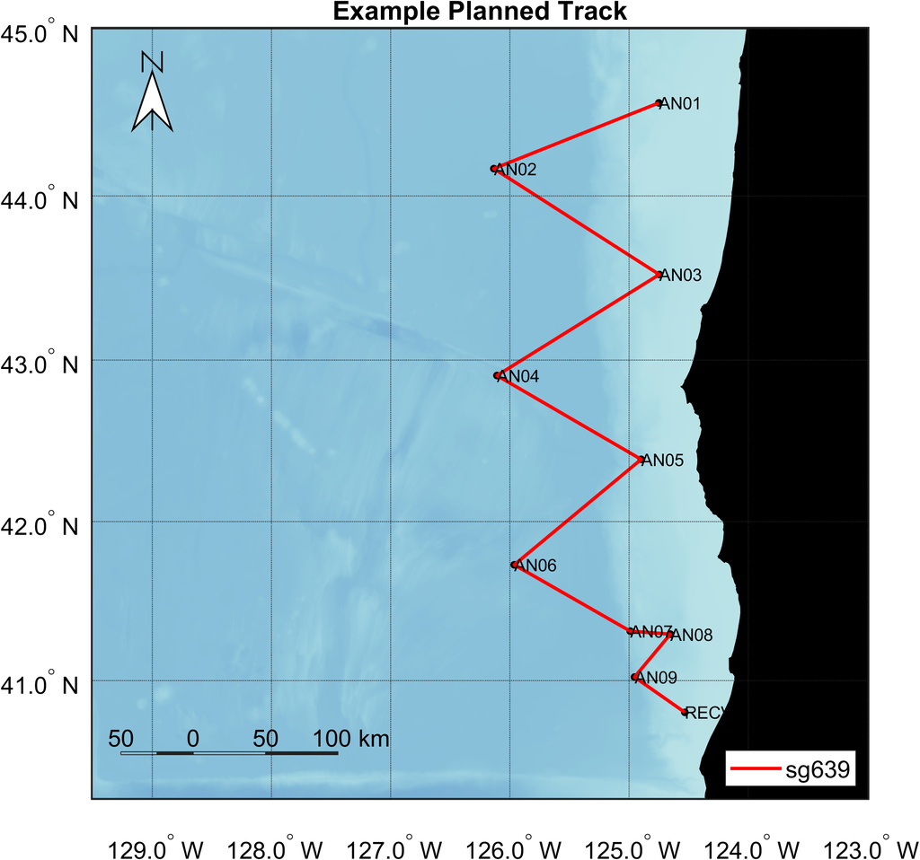

Figure 2: Example of a planned track map with each waypoint labeled.

```
% set up map configuration
bathyOn = 1; % plot bathymetry

% use targetsOut file from above as input targets file
targetsFile = targetsOut;

% create plot
targetsName = mapPlannedTrack(CONFIG, targetsFile, 'trackName', CONFIG.glider, ...
   'bathy', bathyOn, 'col_track', 'red');
% this function uses name-value pairs for optional arguments.
% CONFIG and targetsFile are not optional, but targetsFile may be set to
% empty [] to trigger a prompt to select the targets file

% the title will default to CONFIG.glider CONFIG.mission: targetsName
% This can be very long. To change to whatever you want:
title('Example Planned Track');

% save as .png
exportgraphics(gcf, fullfile(CONFIG.path.mission, [CONFIG.gmStr ...
    '_plannedTrack_' targetsName, '.png']), 'Resolution', 300)
% as .fig
savefig(fullfile(CONFIG.path.mission, [CONFIG.gmStr '_plannedTrack_' ...
    targetsName, '.fig']))
```

<sub>Back to top</sub>

### Plot bathymetry profile

It can be useful to have a profile of the bathymetry the planned track will traverse, to highlight periods where the glider’s target dive depth may need to be adjusted more shallow, or can be extended deeper.

See Dependencies - Basemap rasters for more info on how to select and download bathymetry rasters.

An indicator line (dashed red line) will be plotted at 990 m as the default (max `$D_TGT` for Seagliders) but can be specified to a different value with the `yLine` argument.

NOTE: This function sets the arguments using *name-value* pairs because most of them are optional. So each is defined by the name of the argument in single quotes (e.g., `'bathyFile'`) followed by a comma and then the value for the argument (e.g., `'C:\bathyFile.tiff'`). Use `doc plotTrackBathyProfile` to see all possible arguments.

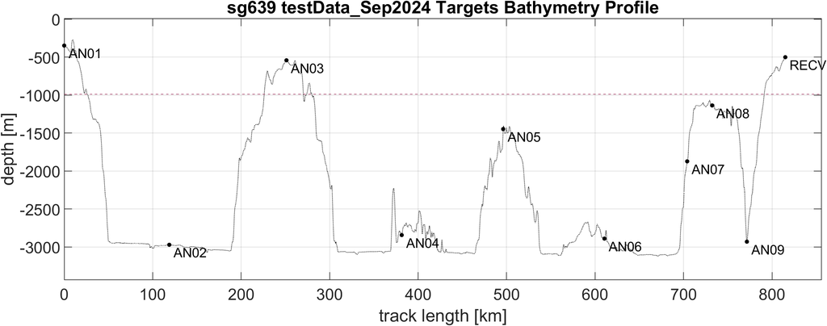

Figure 3: Bathymetry profile for set targets file which shows the seafloor depth at each target and in the straight line between each target. The 990 m depth limit is marked with a dashed line.

```matlab
% can specify bathymetry file and/or targets file
bathyFile = 'C:\GIS\etopo\ETOPO2022_ice_15arcsec_OR_wide.tiff';
targetsFile = fullfile(CONFIG.path.mission, 'targets_exampleTrack');

plotTrackBathyProfile(CONFIG, 'targetsFile', targetsFile, 'bathyFile', bathyFile);

% OR

% leave that argument out to default to CONFIG.map.bathyFile if
% available or prompt if not available
plotTrackBathyProfile(CONFIG, 'targetsFile', targetsFile)

% save as .png
exportgraphics(gcf, fullfile(CONFIG.path.mission, [CONFIG.gmStr ...
    '_targetsBathymetryProfile_' targetsName, '.png']), 'Resolution', 300)
```

### Summarize planned track

The below code reads in an existing (or newly created!) targets file and will loop through to calculate the distance between each waypoint and then print out the total planned track distance. If an estimate of glider speed (in km/day) is available, that can be used to estimate mission duration.

```matlab
% if no targetsFile specified, will prompt to select
[targets, targetsFile] = readTargetsFile(CONFIG);
% OR specify targetsFile variable from above
[targets, targetsFile] = readTargetsFile(CONFIG, targetsFile);

% loop through all targets (expect RECV), calc distance between waypoints
for f = 1:height(targets) - 1
    [targets.distToNext_km(f), ~] = lldistkm([targets.lat(f+1) targets.lon(f+1)], ...
        [targets.lat(f) targets.lon(f)]);
end

% specify expected avg glider speed in km/day
avgSpd = 15; % km/day

% print out summary
[targetsPath, targetsName, ~] = fileparts(targetsFile);
fprintf(1, 'Total tracklength for %s: %.0f km\n', targetsName, ...
    sum(targets.distToNext_km));
fprintf(1, 'Estimated mission duration, at %i km/day: %.1f days\n', avgSpd, ...
    sum(targets.distToNext_km)/avgSpd);
```

The output will look something like this:

[output not shown]

<sub>Back to top</sub>